# 09_pre-post-CURE-exploration

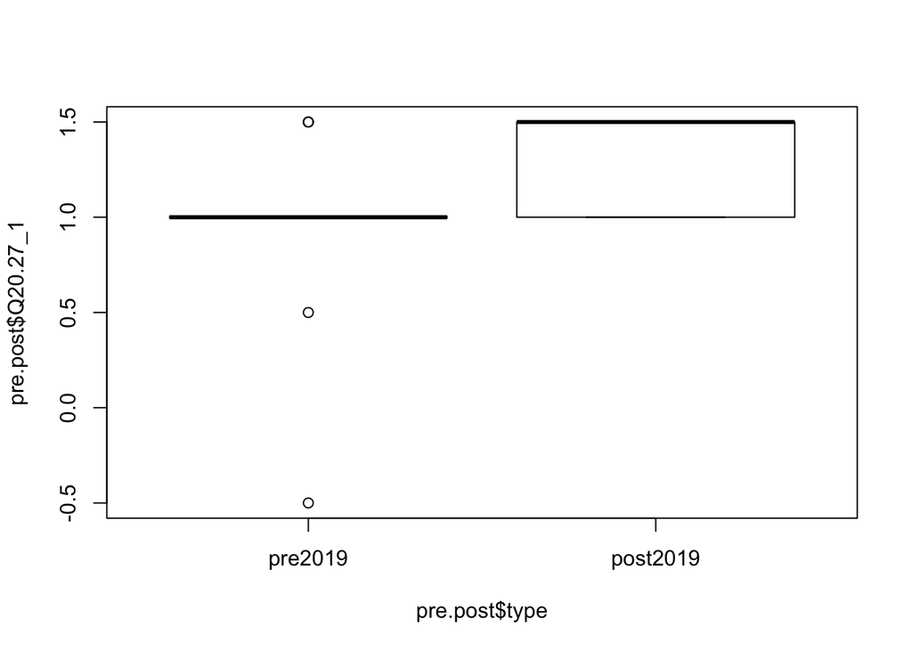

```r
boxplot(pre.post$Q20.27_1 ~ pre.post$type)
```

```r
# Q21. Critically read articles about issues raised in class
# Q21 _ not sig
t.test(pre.post$Q20.27_2 ~ pre.post$type)
```

```
##
##  Welch Two Sample t-test
##
## data:  pre.post$Q20.27_2 by pre.post$type
## t = -0.55355, df = 19.231, p-value = 0.5863
## alternative hypothesis: true difference in means is not equal to 0
## 95 percent confidence interval:
##  -0.4343625  0.2525443
## sample estimates:
##  mean in group pre2019 mean in group post2019
##               1.000000               1.090909
```

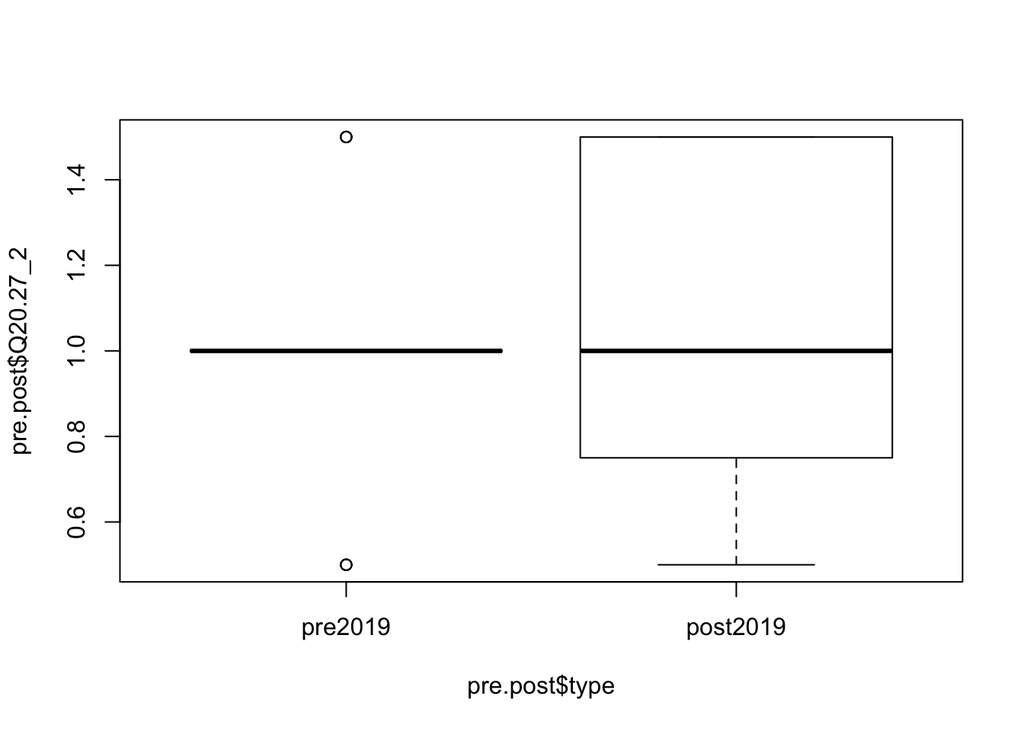

```r
boxplot(pre.post$Q20.27_2 ~ pre.post$type)
```

```r
# Q22. Identify patterns in data
# Q22 _ not sig - same pre/post
t.test(pre.post$Q20.27_3 ~ pre.post$type)
```

```
##
##  Welch Two Sample t-test
##
## data:  pre.post$Q20.27_3 by pre.post$type
## t = 0, df = 21.861, p-value = 1
## alternative hypothesis: true difference in means is not equal to 0
## 95 percent confidence interval:
##  -0.3070981  0.3070981
## sample estimates:
##  mean in group pre2019 mean in group post2019
##                      1                      1
```

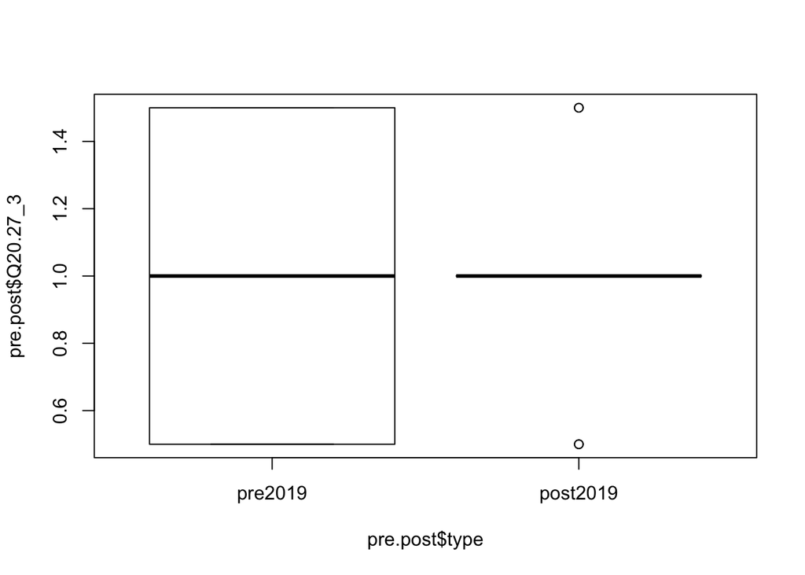

```r
boxplot(pre.post$Q20.27_3 ~ pre.post$type)
```

```r
# Q23. Recognize a sound argument and appropriate use of evidence
# Q23 _ not sig
t.test(pre.post$Q20.27_4 ~ pre.post$type)
```

```
##
##  Welch Two Sample t-test
##
## data:  pre.post$Q20.27_4 by pre.post$type
## t = -1.5543, df = 19.787, p-value = 0.136
## alternative hypothesis: true difference in means is not equal to 0
## 95 percent confidence interval:
##  -0.51610911  0.07554967
## sample estimates:
##  mean in group pre2019 mean in group post2019
##              0.9615385              1.1818182
```

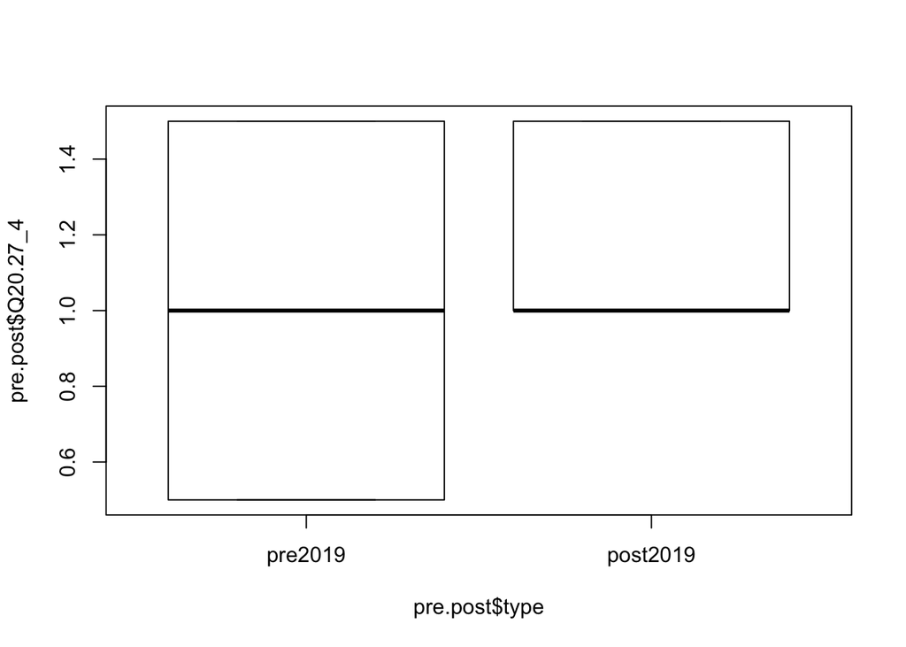

```r
boxplot(pre.post$Q20.27_4 ~ pre.post$type)
```

```r
# Q24. Develop a logical argument
# Q24 _ not sig
t.test(pre.post$Q20.27_5 ~ pre.post$type)
```

```
##
##  Welch Two Sample t-test
##
## data:  pre.post$Q20.27_5 by pre.post$type
## t = -1.0575, df = 21.062, p-value = 0.3023
## alternative hypothesis: true difference in means is not equal to 0
## 95 percent confidence interval:
##  -0.5393108  0.1756744
## sample estimates:
##  mean in group pre2019 mean in group post2019
##               1.000000               1.181818
```

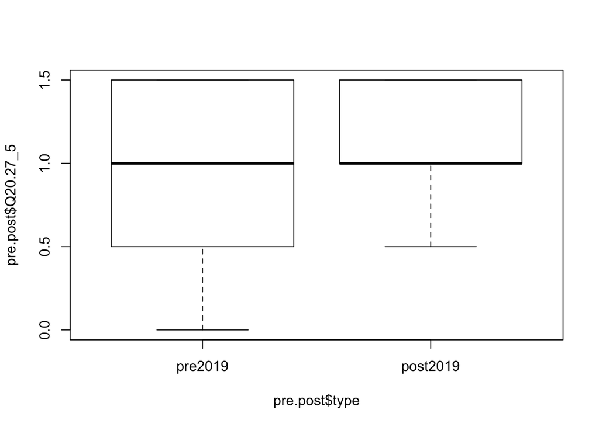

```r
boxplot(pre.post$Q20.27_5 ~ pre.post$type)
```

```r
# Q25. Write documents in discipline-appropriate style and format
# Q25 _ not sig
t.test(pre.post$Q20.27_6 ~ pre.post$type)
```

```
##
##  Welch Two Sample t-test
##
## data:  pre.post$Q20.27_6 by pre.post$type
## t = -1.2845, df = 21.656, p-value = 0.2125
## alternative hypothesis: true difference in means is not equal to 0
## 95 percent confidence interval:
##  -0.7043073  0.1658457
## sample estimates:
##  mean in group pre2019 mean in group post2019
##              0.7307692              1.0000000
```

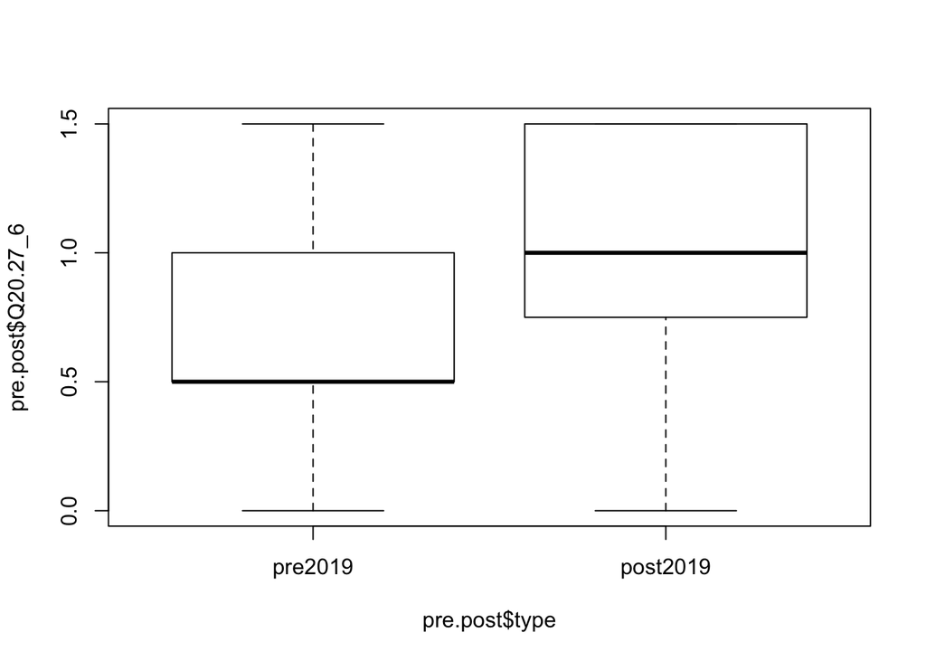

```r
boxplot(pre.post$Q20.27_6 ~ pre.post$type)
```

```r
# Q26. Work effectively with others
# Q26 _ not sig
t.test(pre.post$Q20.27_7 ~ pre.post$type)
```

```
##
##  Welch Two Sample t-test
##
## data:  pre.post$Q20.27_7 by pre.post$type
## t = -0.39339, df = 21.299, p-value = 0.6979
## alternative hypothesis: true difference in means is not equal to 0
## 95 percent confidence interval:
##  -0.2635753  0.1796592
## sample estimates:
##  mean in group pre2019 mean in group post2019
##               1.230769               1.272727
```

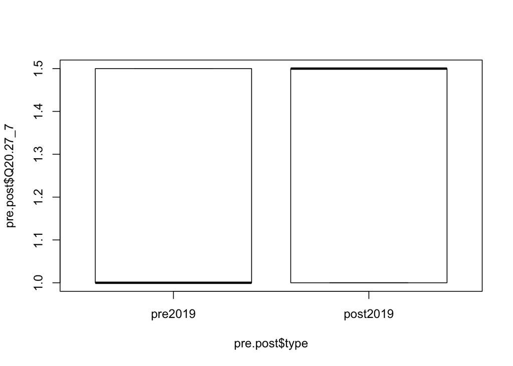

```r
boxplot(pre.post$Q20.27_7 ~ pre.post$type)
```

```r
# Q27. Prepare and give oral presentations
# Q27 _ not sig
t.test(pre.post$Q20.27_8 ~ pre.post$type)
```

```
##
##  Welch Two Sample t-test
##
## data:  pre.post$Q20.27_8 by pre.post$type
## t = -0.37539, df = 20.6, p-value = 0.7112
## alternative hypothesis: true difference in means is not equal to 0
## 95 percent confidence interval:
##  -0.5035673  0.3497212
## sample estimates:
##  mean in group pre2019 mean in group post2019
##              0.9230769              1.0000000
```

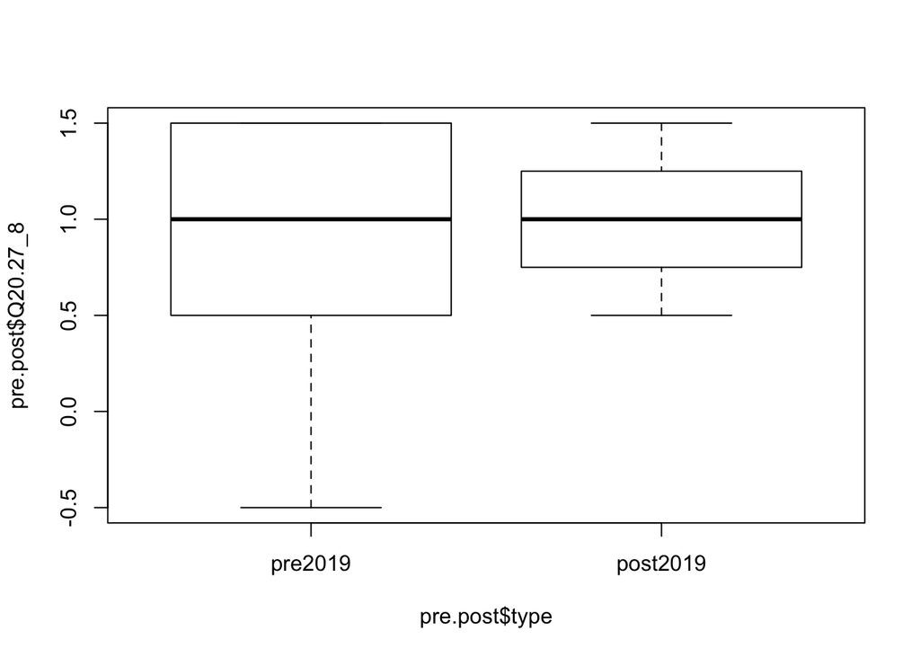

```r
boxplot(pre.post$Q20.27_8 ~ pre.post$type)
```

(SALG) Presently I Understand… Scale Response Category 1 = I gained nothing/not at all 2 = I gained a little 3 = I gained somewhat 4 = I gained a lot 5 = I gained a great deal [different scale than Pre-Assessment] Q28. How ideas we will explore in this class relate to ideas I have encountered in other classes within this subject area Q29. How ideas we will explore in this class relate to ideas I have encountered in classes outside of this subject area Q30. How studying this subject helps people address real world issues

```r
# Q28. How ideas we will explore in this class relate to ideas I have encountered in other classes within this subject area
# Q28 _ not sig
t.test(pre.post$Q28.30_1 ~ pre.post$type)
```

```
##
##  Welch Two Sample t-test
##
## data:  pre.post$Q28.30_1 by pre.post$type
## t = 1.7987, df = 17.334, p-value = 0.0895
## alternative hypothesis: true difference in means is not equal to 0
## 95 percent confidence interval:
##  -0.04281353  0.54281353
## sample estimates:
##  mean in group pre2019 mean in group post2019
##                   0.75                   0.50
```

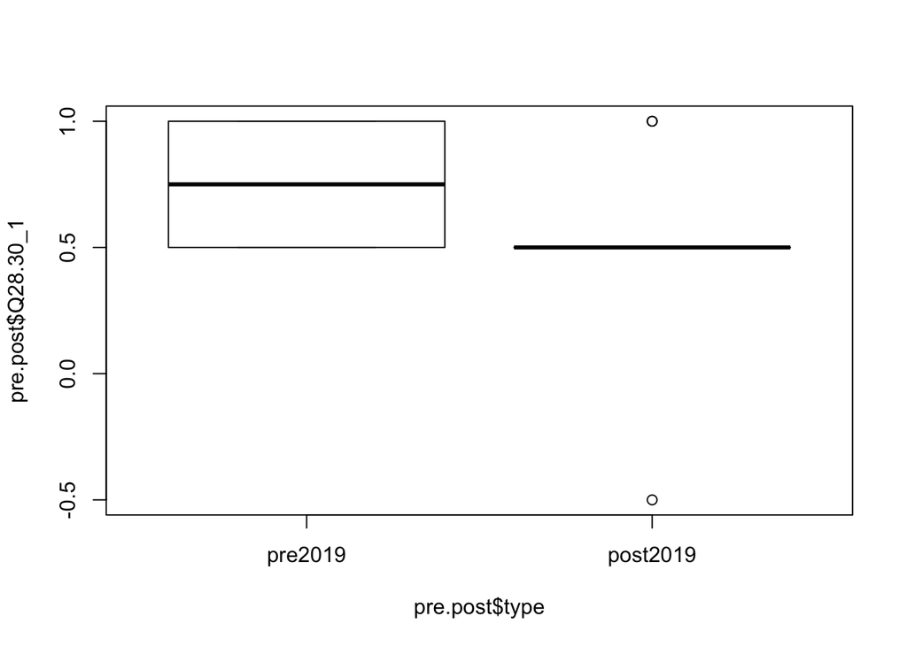

```r
boxplot(pre.post$Q28.30_1 ~ pre.post$type)
```

```r
# Q29. How ideas we will explore in this class relate to ideas I have encountered in classes outside of this subject area
# Q29 _ significant- but the reverse as expected
t.test(pre.post$Q28.30_2 ~ pre.post$type)
```

```
##
##  Welch Two Sample t-test
##
## data:  pre.post$Q28.30_2 by pre.post$type
## t = 2.5555, df = 17.386, p-value = 0.02023
## alternative hypothesis: true difference in means is not equal to 0
## 95 percent confidence interval:
##  0.06392654 0.66334619
## sample estimates:
##  mean in group pre2019 mean in group post2019
##              0.7272727              0.3636364
```

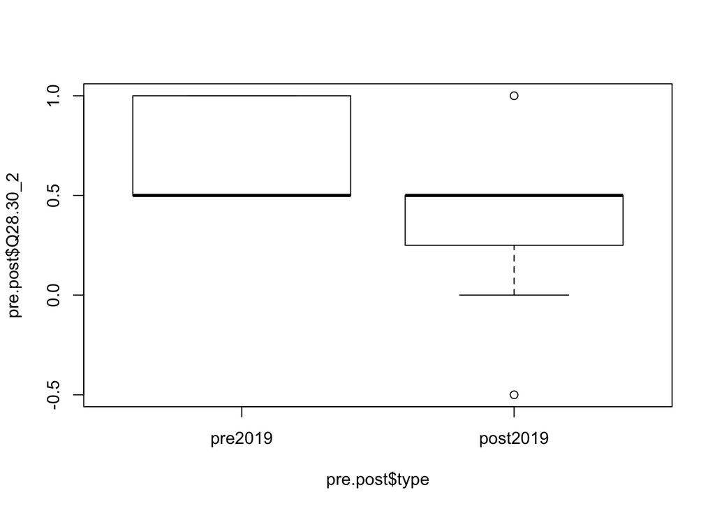

```r
boxplot(pre.post$Q28.30_2 ~ pre.post$type)
```

```r
# Q30. How studying this subject helps people address real world issues
# Q30 _ not sig - but could be without single outlier??
t.test(pre.post$Q28.30_3 ~ pre.post$type)
```

```
##
##  Welch Two Sample t-test
##
## data:  pre.post$Q28.30_3 by pre.post$type
## t = -1.2742, df = 21.033, p-value = 0.2165
## alternative hypothesis: true difference in means is not equal to 0
## 95 percent confidence interval:
##  -0.4325174  0.1038461
## sample estimates:
##  mean in group pre2019 mean in group post2019
##              0.6538462              0.8181818
```

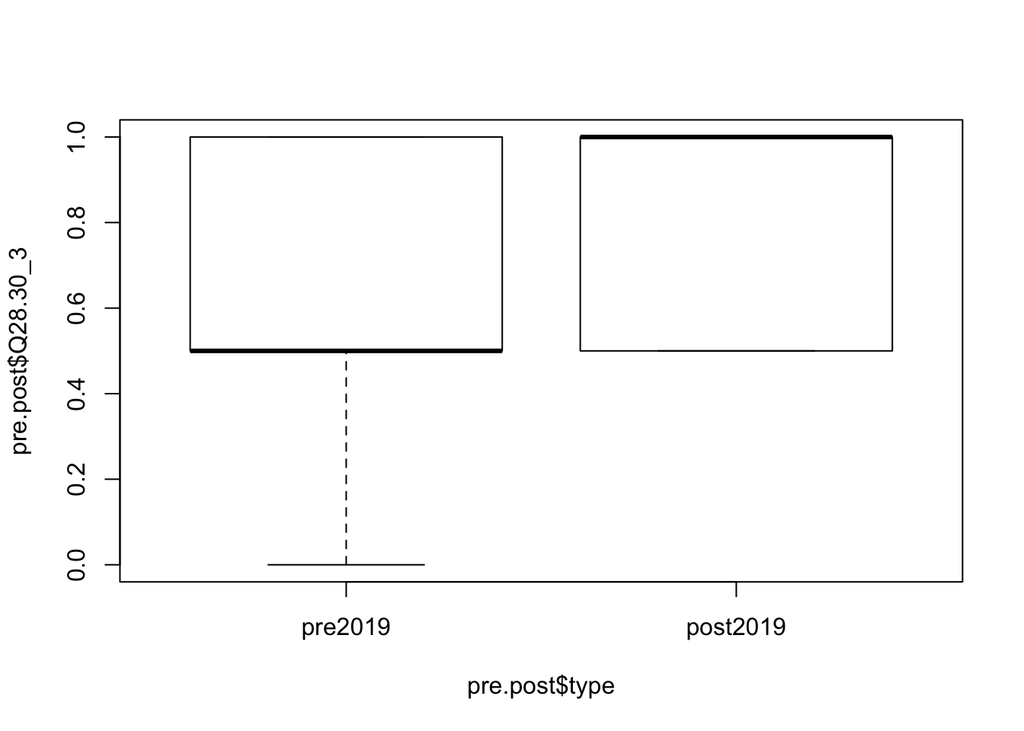

```r
boxplot(pre.post$Q28.30_3 ~ pre.post$type)
```

(SALG) Presently I Am… Scale Response Category 1 = I gained nothing/not at all 2 = I gained a little 3 = I gained somewhat 4 = I gained a lot 5 = I gained a great deal [different scale than Pre-Assessment] Q31. Enthusiastic about this subject Q32. Interested in discussing this subject area with friends or family Q33. Interested in taking or planning to take additional classes in this subject

```r
# Q31. Enthusiastic about this subject
# Q31 _ not sig - but a lot less post test variation
t.test(pre.post$Q31.33_1 ~ pre.post$type)
```

```
##
##  Welch Two Sample t-test
##
## data:  pre.post$Q31.33_1 by pre.post$type
## t = 1.2508, df = 21.574, p-value = 0.2244
## alternative hypothesis: true difference in means is not equal to 0
## 95 percent confidence interval:
##  -0.1269033  0.5115187
## sample estimates:
##  mean in group pre2019 mean in group post2019
##              0.6923077              0.5000000
```

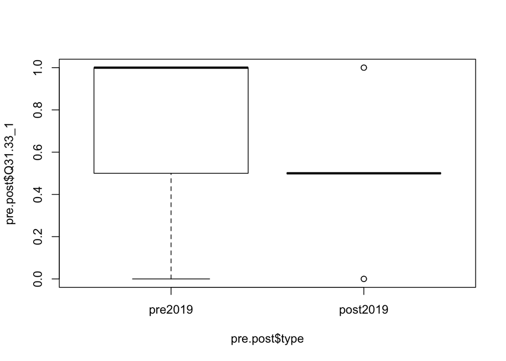

```r
boxplot(pre.post$Q31.33_1 ~ pre.post$type)
```

```r
# Q32.  Interested in discussing this subject area with friends or family
# Q32 _ not sig
t.test(pre.post$Q31.33_2 ~ pre.post$type)
```

```
##
##  Welch Two Sample t-test
##
## data:  pre.post$Q31.33_2 by pre.post$type
## t = 0.36074, df = 21.692, p-value = 0.7218
## alternative hypothesis: true difference in means is not equal to 0
## 95 percent confidence interval:
##  -0.2659420  0.3778301
## sample estimates:
##  mean in group pre2019 mean in group post2019
##              0.6923077              0.6363636
```

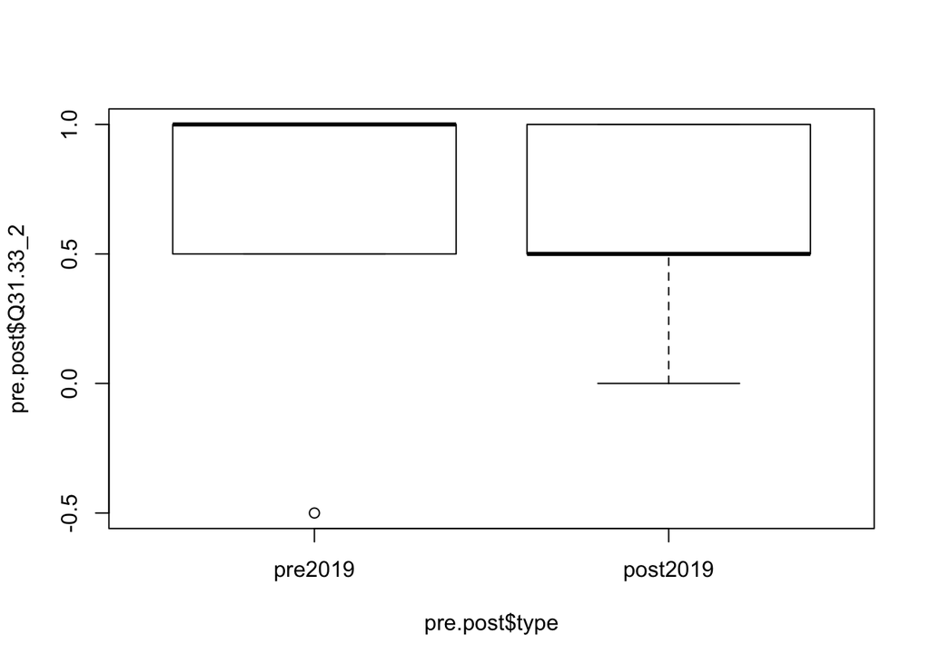

```r
boxplot(pre.post$Q31.33_2 ~ pre.post$type)
```

```r
# Q33. Interested in taking or planning to take additional classes in this subject
# Q33 _ significant - but the reverse as expected
t.test(pre.post$Q31.33_3 ~ pre.post$type)
```

```
##
##  Welch Two Sample t-test
##
## data:  pre.post$Q31.33_3 by pre.post$type
## t = 2.2537, df = 19.183, p-value = 0.0361
## alternative hypothesis: true difference in means is not equal to 0
## 95 percent confidence interval:
##  0.02615002 0.70112271
## sample estimates:
##  mean in group pre2019 mean in group post2019
##              0.8181818              0.4545455
```

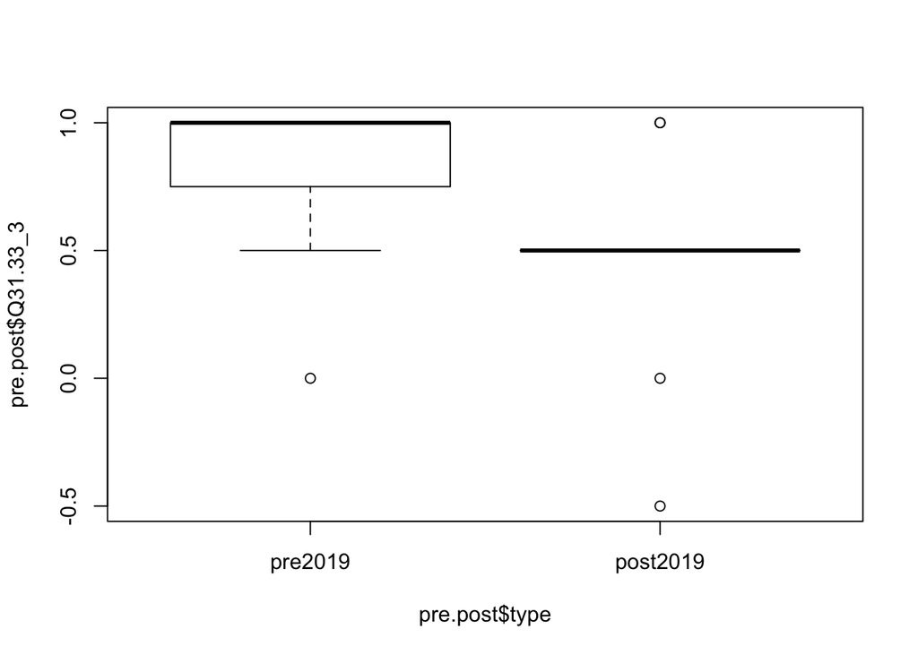

```r
boxplot(pre.post$Q31.33_3 ~ pre.post$type)
```

Community Engagement Rankings: Strongly agree, Agree, Neither agree nor disagree, disagree, strongly disagree, don’t know, prefer not to respond Q34. I know what kinds of foods are grown agriculturally in my community Q35. I know of areas where food can be foraged in or near the city I live Q36. I know what kinds of tree species are found in my community Q37. I know what kinds of diseases local foresters and agriculturalists manage in Boulder Q38. I have met people who work in urban agriculture systems Q39. I could tell a story about the environment at a place in or near the city I live Q40. I could tell a story about the history of a place in or near the city I live

```r
calcSE <- function(x){sd(x)/sqrt(length(x))}

# Q34. I know what kinds of foods are grown agriculturally in my community
#Q34 - 0.07- not signficant
t.test(pre.post$Q34.40_1 ~ pre.post$type)
```

```
##
##  Welch Two Sample t-test
##
## data:  pre.post$Q34.40_1 by pre.post$type
## t = -1.8836, df = 19.713, p-value = 0.07446
## alternative hypothesis: true difference in means is not equal to 0
## 95 percent confidence interval:
##  -0.98935985  0.05089831
## sample estimates:
##  mean in group pre2019 mean in group post2019
##             -0.2692308              0.2000000
```

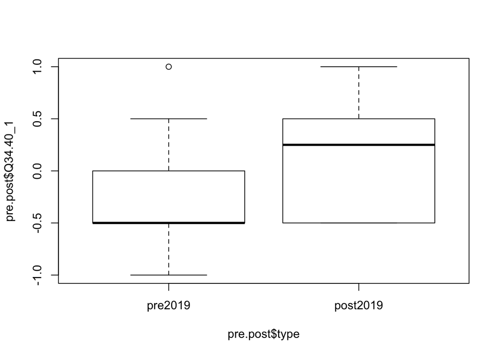

```r
boxplot(pre.post$Q34.40_1 ~ pre.post$type)
```

```r
# Let's look at our group means and st errors
Q34.m <- aggregate(Q34.40_1~type, data=pre.post, mean)
Q34.m
```

```
##       type   Q34.40_1
## 1  pre2019 -0.2692308
## 2 post2019  0.2000000
```

```r
Q34.sd <- aggregate(Q34.40_1~type, data=pre.post, calcSE)
Q34.sd
```

```
##       type  Q34.40_1
## 1  pre2019 0.1661728
## 2 post2019 0.1855921
```

```r
# Q35. I know of areas where food can be foraged in or near the city I live
#Q35 - significant
t.test(pre.post$Q34.40_2 ~ pre.post$type)
```

```
##
##  Welch Two Sample t-test
##
## data:  pre.post$Q34.40_2 by pre.post$type
## t = -2.7009, df = 20.825, p-value = 0.01345
## alternative hypothesis: true difference in means is not equal to 0
## 95 percent confidence interval:
##  -1.2318341 -0.1597743
## sample estimates:
##  mean in group pre2019 mean in group post2019
##             -0.4230769              0.2727273
```

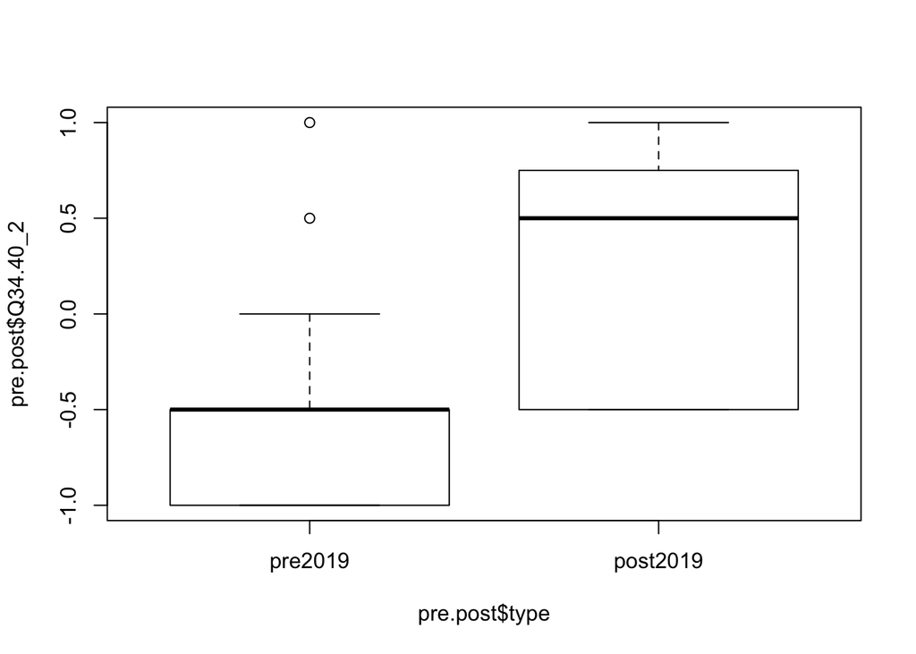

```r
boxplot(pre.post$Q34.40_2 ~ pre.post$type)
```

```r
# Q36. I know what kinds of tree species are found in my community
#Q36 - significant
t.test(pre.post$Q34.40_3 ~ pre.post$type)
```

```
##
##  Welch Two Sample t-test
##
## data:  pre.post$Q34.40_3 by pre.post$type
## t = -2.8696, df = 20.751, p-value = 0.009246
## alternative hypothesis: true difference in means is not equal to 0
## 95 percent confidence interval:
##  -1.1305556 -0.1800505
## sample estimates:
##  mean in group pre2019 mean in group post2019
##             -0.2916667              0.3636364
```

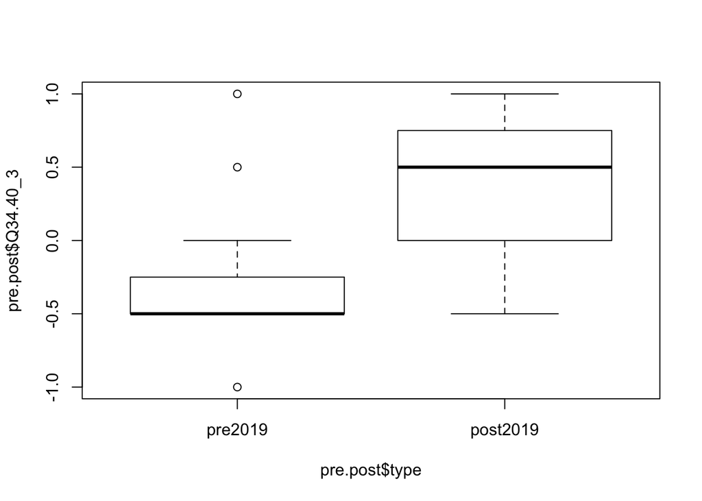

```r
boxplot(pre.post$Q34.40_3 ~ pre.post$type)
```

```r
# Q37. I know what kinds of diseases local foresters and agriculturalists manage in Boulder
#Q37 - significant
t.test(pre.post$Q34.40_4 ~ pre.post$type)
```

```
##
##  Welch Two Sample t-test
##
## data:  pre.post$Q34.40_4 by pre.post$type
## t = -2.6477, df = 21.728, p-value = 0.0148
## alternative hypothesis: true difference in means is not equal to 0
## 95 percent confidence interval:
##  -1.1164687 -0.1352796
## sample estimates:
##  mean in group pre2019 mean in group post2019
##             -0.3076923              0.3181818
```

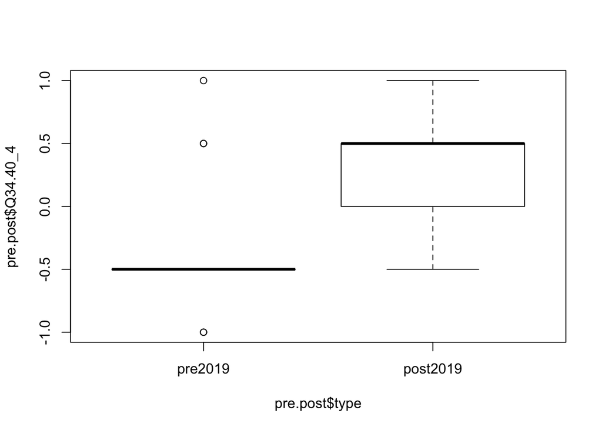

```r
boxplot(pre.post$Q34.40_4 ~ pre.post$type)
```